# Face Analysis Technology Evaluation (FATE) PAD

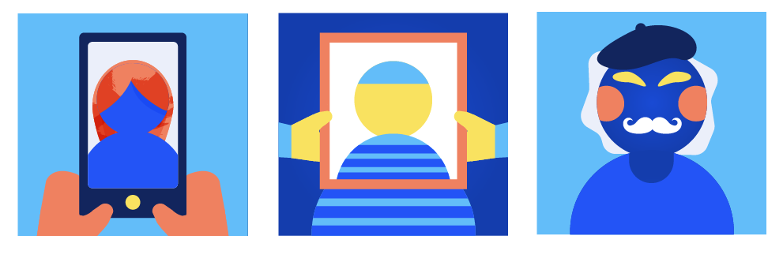

Credit: Natasha Hanacek/NIST

[Report](https://doi.org/10.6028/NIST.IR.8491) | [Participation Agreement](https://pages.nist.gov/frvt/agreements/frvt_participation_agreement.pdf) | [API](https://pages.nist.gov/frvt/api/FRVT_pad_api.pdf) | Validation | [Encryption](https://www.nist.gov/itl/iad/image-group/products-and-services/encrypting-softwaredata-transmission-nist)

**This track is currently closed**, and NIST is not accepting PAD submissions for evaluation at this time. An announcement will be made on this website and to our mailing list when this track reopens.

**[2023-09-20]** We have released [NISTIR 8491](https://doi.org/10.6028/NIST.IR.8491) - Face Analysis Technology Evaluation (FATE) Part 10: Performance of Passive, Software-based Presentation Attack Detection (PAD) Algorithms. As described in this [press release](https://www.nist.gov/news-events/news/2023/09/whats-wrong-picture-nist-face-analysis-program-helps-find-answers), the report quantifies the accuracy of 82 passive face PAD algorithms (software only, no hardware solutions) operating on conventional 2D imagery of various presentation attack instruments.

**[2023-08-18]** FRVT was split and renamed to [FRTE](https://www.nist.gov/programs-projects/face-technology-evaluations-frtefate) and [FATE](https://www.nist.gov/programs-projects/face-technology-evaluations-frtefate).

A presentation attack (PA), as defined by the ISO/IEC 30107 standard on biometric presentation attack detection, is “the presentation of an artefact or of human characteristics to a biometric capture subsystem in a fashion intended to interfere with system policy”. A presentation attack is often launched with the intent of impersonation (the user is trying to authenticate as a target identity) or evasion (the user is trying to fool the biometric system into not recognizing their true identity). The goals of impersonation include trying to gain positive access privilege as someone else, for example, trying to unlock someone’s cell phone or gain access to a facility. The goals of evasion are typically to conceal one’s true identity to evade recognition from say a watchlist, or to create a separate enrollment under a different name. Biometric systems can potentially be attacked by an unknown number of presentation attack instruments, and the number or type of attack instruments in existence is not well-known. Some examples of known presentation attack instruments include artificial “gummy” fingers, “replay” attacks where the attacker is holding a photo or video of someone’s face to the camera, and iris photo and contact lens attacks. Presentation attack of face recognition systems (and the ability to detect it) is an area of high interest given the widespread deployment of face recognition systems, particularly in unmanned/unsupervised and remote enrollment and authentication scenarios.

To participate in this evaluation, developers need to submit a participation agreement to NIST, wrap their software behind the published C++ API, run their libraries through the provided validation package (which creates a submission package), encrypt the package, and provide a download link for the encrypted submission package. More details are provided below.

### Participation Agreement

FATE is conducted by NIST, an agency of the United States Government. Participation is free of charge. FATE is open to a global audience of face recognition developers. All organizations who seek to participate in FATE must sign all pages of this [Participation Agreement](https://pages.nist.gov/frvt/agreements/frvt_participation_agreement.pdf) and submit it with their algorithm submission using the [Submission Form](https://pages.nist.gov/frvt/html/frvt_submission_form.html). [last update: 2023-07-03]

[NOTE:] Organizations that have already submitted a participation agreement for FRTE Ongoing 1:1 do not need to send in a new participation agreement UNLESS the organization updates their cryptographic signing key.

### API Document

A definitive [API document](https://pages.nist.gov/frvt/api/FRVT_pad_api.pdf) has been published. All algorithms submitted must adhere to the published C++ API. [last update: 2022-10-04]

### Validation

A [validation package](https://github.com/usnistgov/frvt) has been published. All participants must run their software through the validation package prior to submission. The purpose of validation is to ensure consistent algorithm output between your execution and NIST’s execution. [last update: 2023-04-28]

### Encryption

All submissions must be properly encrypted and signed before transmission to NIST. This must be done according to these [instructions](https://www.nist.gov/system/files/documents/2021/10/25/nist_encryption.pdf) using the FRTE Ongoing public key linked from this [page](https://www.nist.gov/itl/iad/image-group/products-and-services/encrypting-softwaredata-transmission-nist). Participants must email their public key to NIST. The participant’s public key must correspond to the participant’s public-key fingerprint provided on the signed Participation Application. [last update: 2022-08-22]

### Submission

All algorithm submissions must be submitted through the [Submission Form](https://pages.nist.gov/frvt/html/frvt_submission_form.html), which requires encrypted files be provided as a download link from a generic http server (e.g., Google Drive). We cannot accept Dropbox links. NIST will not register, or establish any kind of membership, on the provided website. Participants can submit their algorithm(s), participation agreement, and GPG key at the same time via the submission form. [last update: 2023-07-03]

Participants must subscribe to the FATE mailing list to receive emails when new reports are published or announcements are made.

Inquiries and comments may be submitted to frvt@nist.gov. Subscribe to the evaluation mailing list to receive emails when announcements or updates are made.